# Sample Point-Biserial Correlation (Small Data Samples)

Kyaw Min Khaing

2025-01-29

## Introduction

This analysis applies the **Point-Biserial Correlation** to examine the relationship between **Gender (binary variable: Male/Female)** and **Posttest Scores** for a small dataset.

## Step 1: State the Hypotheses

- **Null Hypothesis (H₀):** There is no significant correlation between gender and posttest scores.
- **Alternative Hypothesis (H₁):** There is a significant correlation between gender and posttest scores.

## Step 2: Set the Level of Significance

We set **α = 0.05** as the significance level.

## Step 3: Load and Prepare Data

```r
data <- tibble(
  Participant = 1:17,
  Gender = c(rep("M", 8), rep("F", 9)),
  Posttest_Score = c(7, 19, 8, 10, 7, 15, 6, 13, 14, 11, 18, 23, 17, 20, 14, 24, 22)
  ) %>% mutate(Gender_Binary = ifelse(Gender == "M", 0, 1))

print(data)
```

```
## # A tibble: 17 × 4
##    Participant Gender Posttest_Score Gender_Binary
##          <int> <chr>           <dbl>         <dbl>
##  1           1 M                   7             0
##  2           2 M                  19             0
##  3           3 M                   8             0
##  4           4 M                  10             0
##  5           5 M                   7             0
##  6           6 M                  15             0
##  7           7 M                   6             0
##  8           8 M                  13             0
##  9           9 F                  14             1
## 10          10 F                  11             1
## 11          11 F                  18             1
## 12          12 F                  23             1
## 13          13 F                  17             1
## 14          14 F                  20             1
## 15          15 F                  14             1
## 16          16 F                  24             1
## 17          17 F                  22             1
```

```r
n <- nrow(data)
```

## Step 4: Compute Point-Biserial Correlation

The formula for Point-Biserial Correlation is:

where: - $M_1$ is the mean of the continuous variable for one group (e.g., females). - $M_0$ is the mean of the continuous variable for the other group (e.g., males). - $s$ is the standard deviation of the continuous variable. - $p_1$ is the proportion of one group. - $p_0$ is the proportion of the other group. The mean females’ posttest score

[output not shown]

The mean males’ posttest score

```r
M_0 <- mean(data %>% filter(Gender_Binary == 0) %>% pull(Posttest_Score))
glimpse(M_0 )
```

```
##  num 10.6
```

standard deviation for the interval data

```r
s <- sd(data$Posttest_Score)
glimpse(s)
```

```
##  num 5.86
```

number of males and females

```r
n <- nrow(data)
glimpse(n )
```

```
##  int 17
```

number of females

```r
n_1 <- sum(data$Gender_Binary == 1)
glimpse(n_1)
```

```
##  int 9
```

Proportion of females

```r
p_1 <- n_1 / n
glimpse(p_1)
```

```
##  num 0.529
```

number of males

```r
n_0 <- sum(data$Gender_Binary == 0)
glimpse(n_0)
```

```
##  int 8
```

Proportion of males

```r
p_0 <- n_0 / n
glimpse(p_0)
```

```
##  num 0.471
```

```r
r_pb <- ((M_0 - M_1) / s) * sqrt(p_0 * p_1)
glimpse(r_pb)
```

```
##  num -0.637
```

## Step 6: Compare the Obtained Value with the Critical Value

```r
if (abs(r_pb) >= 0.482) {
  cat("The correlation is statistically significant. We reject H₀ and conclude there is a significant correlation.\n")
} else {
  cat("The correlation is not statistically significant. We fail to reject H₀.\n")
}
```

```
## The correlation is statistically significant. We reject H₀ and conclude there is a significant correlation.
```

## Step 7: Interpret the Results

If **|r_pb| ≥ 0.482**, the result is significant.

## Step 9: Data Visualization

To better understand the distribution of posttest scores by gender, we visualize it using `ggplot2`.

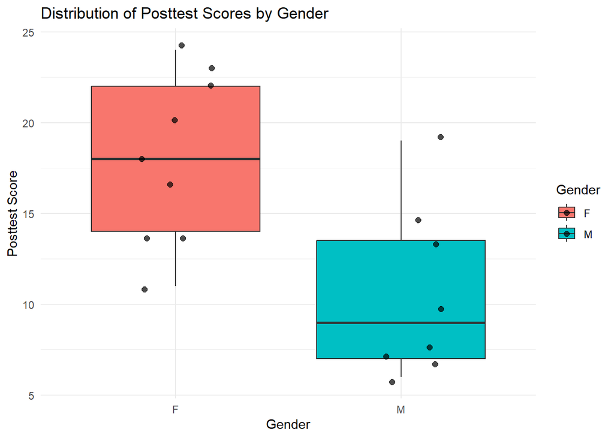

```r
data_long <- data %>%
  pivot_longer(cols = Posttest_Score, names_to = "Variable", values_to = "Score")

ggplot(data_long, aes(x = Gender, y = Score, fill = Gender)) +
  geom_boxplot(outlier.color = "red", outlier.shape = 8) +
  geom_jitter(width = 0.2, size = 2, alpha = 0.7) +
  labs(
    title = "Distribution of Posttest Scores by Gender",
    x = "Gender",
    y = "Posttest Score"
  ) +
  theme_minimal()
```